# Homework_8_Wu_Inessa

Inessa Wu

March 20, 2018

```r
library (tidyverse)
library (rmarkdown)
library (mosaicData)
library (lubridate)
library(broom)
library(rpart)
library(partykit)
library(ROCR)
```

### Exercise 1

Titanic file contains 891 observations and 12 variables (columns)

```r
#Import titanic file
file_path <- 'C:/Users/ipodvorna/Documents/compscix-415-2-assignments/compscix-415-2-assignments/titanic.csv'
titanic_data <- read_delim(file = file_path, delim = ",")

glimpse(titanic_data)
```

```
## Observations: 891
## Variables: 12
## $ PassengerId <int> 1, 2, 3, 4, 5, 6, 7, 8, 9, 10, 11, 12, 13, 14, 15,...
## $ Survived    <int> 0, 1, 1, 1, 0, 0, 0, 0, 1, 1, 1, 1, 0, 0, 0, 1, 0,...
## $ Pclass      <int> 3, 1, 3, 1, 3, 3, 1, 3, 3, 2, 3, 1, 3, 3, 3, 2, 3,...
## $ Name        <chr> "Braund, Mr. Owen Harris", "Cumings, Mrs. John Bra...
## $ Sex         <chr> "male", "female", "female", "female", "male", "mal...
## $ Age         <dbl> 22, 38, 26, 35, 35, NA, 54, 2, 27, 14, 4, 58, 20, ...
## $ SibSp       <int> 1, 1, 0, 1, 0, 0, 0, 3, 0, 1, 1, 0, 0, 1, 0, 0, 4,...
## $ Parch       <int> 0, 0, 0, 0, 0, 0, 0, 1, 2, 0, 1, 0, 0, 5, 0, 0, 1,...
## $ Ticket      <chr> "A/5 21171", "PC 17599", "STON/O2. 3101282", "1138...
## $ Fare        <dbl> 7.2500, 71.2833, 7.9250, 53.1000, 8.0500, 8.4583, ...
## $ Cabin       <chr> NA, "C85", NA, "C123", NA, NA, "E46", NA, NA, NA, ...
## $ Embarked    <chr> "S", "C", "S", "S", "S", "Q", "S", "S", "S", "C", ...
```

```r
#Converst Survived to factor

titanic_data <- titanic_data %>% mutate(Survived_fct = factor(Survived)) %>% select(-Survived)
titanic_data <- titanic_data %>% mutate(Pclass_fct = factor(Pclass)) %>% select(-Pclass)

glimpse(titanic_data)
```

```
## Observations: 891
## Variables: 12
## $ PassengerId  <int> 1, 2, 3, 4, 5, 6, 7, 8, 9, 10, 11, 12, 13, 14, 15...
## $ Name         <chr> "Braund, Mr. Owen Harris", "Cumings, Mrs. John Br...
## $ Sex          <chr> "male", "female", "female", "female", "male", "ma...
## $ Age          <dbl> 22, 38, 26, 35, 35, NA, 54, 2, 27, 14, 4, 58, 20,...
## $ SibSp        <int> 1, 1, 0, 1, 0, 0, 0, 3, 0, 1, 1, 0, 0, 1, 0, 0, 4...
## $ Parch        <int> 0, 0, 0, 0, 0, 0, 0, 1, 2, 0, 1, 0, 0, 5, 0, 0, 1...
## $ Ticket       <chr> "A/5 21171", "PC 17599", "STON/O2. 3101282", "113...
## $ Fare         <dbl> 7.2500, 71.2833, 7.9250, 53.1000, 8.0500, 8.4583,...
## $ Cabin        <chr> NA, "C85", NA, "C123", NA, NA, "E46", NA, NA, NA,...
## $ Embarked     <chr> "S", "C", "S", "S", "S", "Q", "S", "S", "S", "C",...
## $ Survived_fct <fct> 0, 1, 1, 1, 0, 0, 0, 0, 1, 1, 1, 1, 0, 0, 0, 1, 0...
## $ Pclass_fct   <fct> 3, 1, 3, 1, 3, 3, 1, 3, 3, 2, 3, 1, 3, 3, 3, 2, 3...
```

### Exercise #2

Splitting data into training and test data sets (70/30)

```r
# Setting a seed to guarantee that the same random sample is
# generated every time, so long as the same seed is set beforehand

set.seed(29283)

# Creating training data set - 70% of data
titanic_train_set <- titanic_data %>% sample_frac(.7)

# Assigning the remaining 30% of data to testing data set
titanic_test_set <- titanic_data %>% filter(!(PassengerId %in% titanic_train_set$PassengerId))
```

### Exercise 3

What kind of relationship will these features have with the probability of survival?

Based on known history of Titanic, the evacuation prioroty was given to higher class passengers, women, and children. SO I would expect the probablity of survival to be higher for higher class passenger (the highest for 1st class), higher for women. The fare should be closely correlated with the class of the ticket; not sure it would add much to the model.

Are these good features, given the problem we are trying to solve? Sex and Pclass are good feartures based on the statement above. Sex might nt be the best since it’s higly correlated with Pclass. Age might be a good feature to add since priority was given to children as well and younger poeple had somewhat higher change of surviving in freezing waters

```r
# Fit a model with intercept only
mod_1 <- glm(Survived_fct ~ Pclass_fct + Sex + Fare, data = titanic_train_set, family = 'binomial')

# take a look at the features and coefficients
tidy(mod_1)
```

```
##          term     estimate   std.error   statistic      p.value
## 1 (Intercept)  2.184273582 0.328033129   6.6586981 2.762637e-11
## 2 Pclass_fct2 -0.633237694 0.321525515  -1.9694788 4.889813e-02
## 3 Pclass_fct3 -1.701756611 0.298007147  -5.7104557 1.126741e-08
## 4     Sexmale -2.834542001 0.229213455 -12.3663857 3.973000e-35
## 5        Fare  0.002266955 0.002360593   0.9603331 3.368876e-01
```

Coefficient interpretation: intercept: 2.18 log odds for Female, Passenger class 1 passengers to survive The log odds of survival for a passenger in 2nd class, holding male and fare constant is 0.633 lower The log odds of survival for a passenger in 3rd class, holding male and fare constant is 1.70 lower The log odds of survival for a male passenger, holding passenger class and fare constant is 2.83 lower

Are the features significant? Fare is not asignificant feature since it has a fairly high p-value of 0.337, higher than typical threshold of 0.05

### Exercise 4

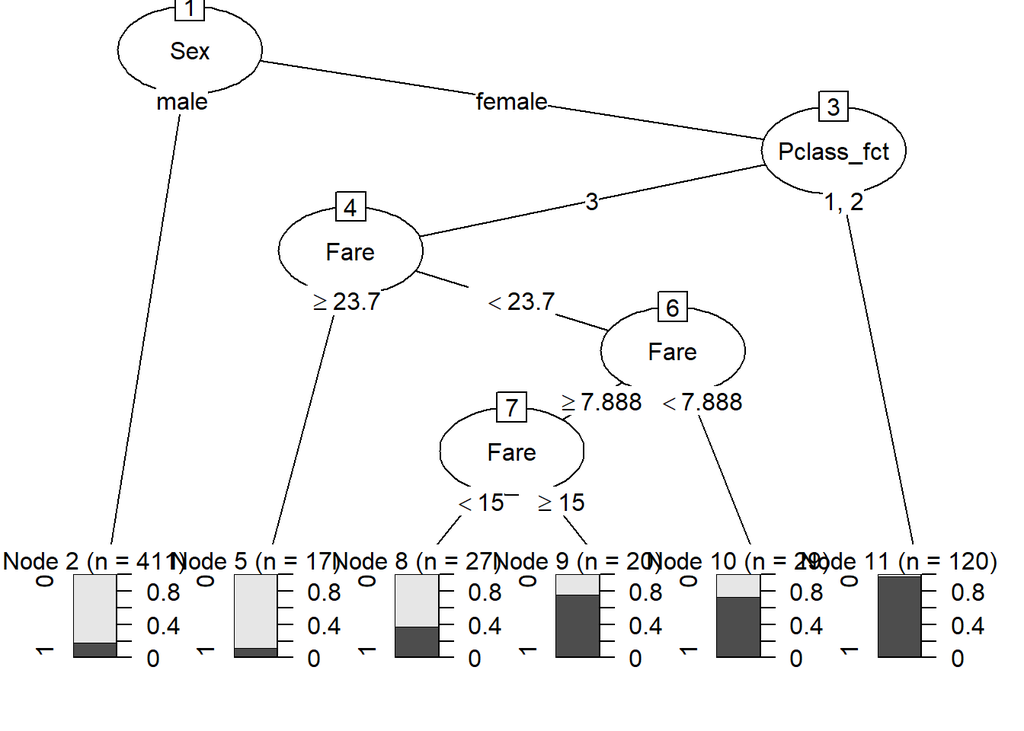

```r
tree_mod <- rpart(Survived_fct ~ Pclass_fct + Sex + Fare, data = titanic_train_set)

plot(as.party(tree_mod))
```

Describing one path a Titanic passenger:

A male passenger had on average a low probability of survival. The only passenger segment that had even lower probability of survival were female passengers who had 3rd class ticket and paid less that more than 23.7 for their fare

The surprising output of the tree is that it does not seem to differentiate probablity of survival for male passengers regardless of class of ticket and fare paid. Also it is surprising that female passengers, traveling 3rd class, paying higher fare had lower probability or survival that females other females traveling the same class but paying lower fares. The only possible explanation is that the damage to the ship happened in the area where higher priced 3rd class cabins where and those portions on the ship were sealed off first.

### Exercise 5

```r
#Evaluate both the logistic regression model and classification tree on the titanic_test_set
test_logit <- predict(mod_1, newdata = titanic_test_set, type = 'response')
test_tree <- predict(tree_mod, newdata = titanic_test_set)[,2]
head(test_tree)
```

```
##         1         2         3         4         5         6
## 0.1776156 0.9666667 0.1776156 0.9666667 0.7500000 0.3703704
```

1. Plot the ROC curves from both models

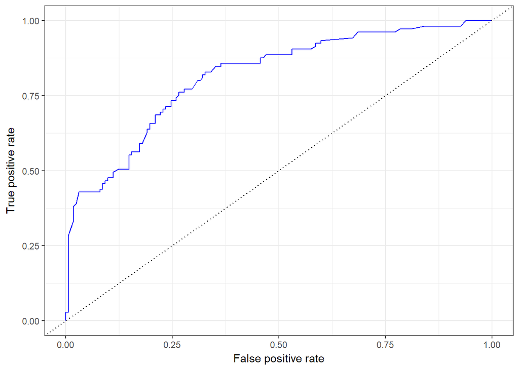

```r
# create the prediction objects for both models
pred_logit <- prediction(predictions = test_logit, labels = titanic_test_set$Survived_fct)
pred_tree <- prediction(predictions = test_tree, labels = titanic_test_set$Survived_fct)

# get the FPR and TPR for the logistic model
# recall that the ROC curve plots the FPR on the x-axis
perf_logit <- performance(pred_logit, measure = 'tpr', x.measure = 'fpr')
perf_logit_tbl <- tibble(perf_logit@x.values[[1]], perf_logit@y.values[[1]])

# Change the names of the columns of the tibble
names(perf_logit_tbl) <- c('fpr', 'tpr')

# get the FPR and TPR for the tree model
perf_tree <- performance(pred_tree, measure = 'tpr', x.measure = 'fpr')
perf_tree_tbl <- tibble(perf_tree@x.values[[1]], perf_tree@y.values[[1]])

# Change the names of the columns of the tibble
names(perf_tree_tbl) <- c('fpr', 'tpr')

# Plotting function for plotting a nice ROC curve using ggplot
plot_roc <- function(perf_tbl) {
  p <- ggplot(data = perf_tbl, aes(x = fpr, y = tpr)) +
  geom_line(color = 'blue') +
  geom_abline(intercept = 0, slope = 1, lty = 3) +
  labs(x = 'False positive rate', y = 'True positive rate') +
  theme_bw()
  return(p)
}

# Create the ROC curves using the function we created above
plot_roc(perf_logit_tbl)
```

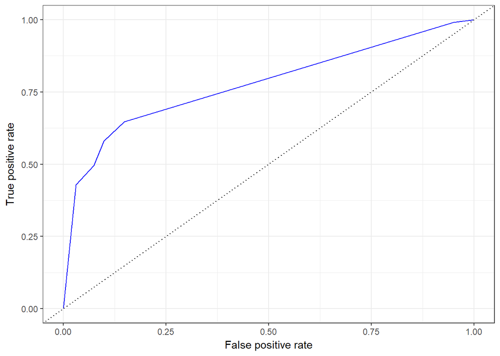

```r
plot_roc(perf_tree_tbl)
```

2. Calculate the area under the curve (AUC) for both ROC curves

```r
# calculate the AUC
auc_logit <- performance(pred_logit, measure = "auc")
auc_tree <- performance(pred_tree, measure = "auc")

# extract the AUC value
auc_logit@y.values[[1]]
```

```
## [1] 0.8147854
```

```r
auc_tree@y.values[[1]]
```

```
## [1] 0.776602
```

Both models have higher than 50% AUC which indicates prediction better than random. AUC for logistic regression model is better than the one for the diecision tree. However, the rate of false positive increases much faster for the logistics regression model.

```r
#Adding a column with the predicted survival (Y/N) - logistics regression model

titanic_logit <- titanic_test_set %>% mutate(preds_prob_log = test_logit) %>%
  mutate(preds_cat = case_when(preds_prob_log < .25 ~ 'No',
                               preds_prob_log >= .25 ~ 'Yes'))
titanic_logit %>% count(preds_cat)
```

```
## # A tibble: 2 x 2
##   preds_cat     n
##   <chr>     <int>
## 1 No          133
## 2 Yes         134
```

```r
#create confusion matrix - logistic regression model

titanic_logit %>% count(preds_cat, Survived_fct) %>% spread(Survived_fct, n)
```

```
## # A tibble: 2 x 3
##   preds_cat   `0`   `1`
##   <chr>     <int> <int>
## 1 No          112    21
## 2 Yes          50    84
```

```r
#Adding a column with the predicted survival (Y/N) - decision tree model

titanic_tree <- titanic_test_set %>% mutate(preds_prob_tree = test_tree) %>%
  mutate(preds_cat = case_when(preds_prob_tree < .25 ~ 'No',
                               preds_prob_tree >= .25 ~ 'Yes'))
titanic_tree %>% count(preds_cat)
```

```
## # A tibble: 2 x 2
##   preds_cat     n
##   <chr>     <int>
## 1 No          175
## 2 Yes          92
```

```r
#create confusion matrix - decision tree model

titanic_tree %>% count(preds_cat, Survived_fct) %>% spread(Survived_fct, n)
```

```
## # A tibble: 2 x 3
##   preds_cat   `0`   `1`
##   <chr>     <int> <int>
## 1 No          138    37
## 2 Yes          24    68
```